# DDP Course Project

May 5, 2017

## My Shiny Application

[Exploring Mtcars Dataset](https://guillermopachon.shinyapps.io/DDP_CourseProject/)

This is a basic exploratory application using the `mtcars` dataset.

In the first part, the application describes the dataset that we are gong to explore.

In the second part, the application allows the user select variables (*predictor-outcome*), and check the interaction of the variables through a plot and a basic linear model.

Here, the user will find easy steps about the use of the available options, like: select columns, toggle points (remove/include to the model), view model results.

## Introduction

The user is introduced to `mtcars` dataset:

- Where it comes from.
- Variables (aspects) and description of them. Number of rows.

## Interaction

In this section, the user can:

- Select columns to plot.
- Remove/include poins to the model.
- View the points used and view the linear model summary.

By default, the application will show the interaction between `mpg` and `wt`.

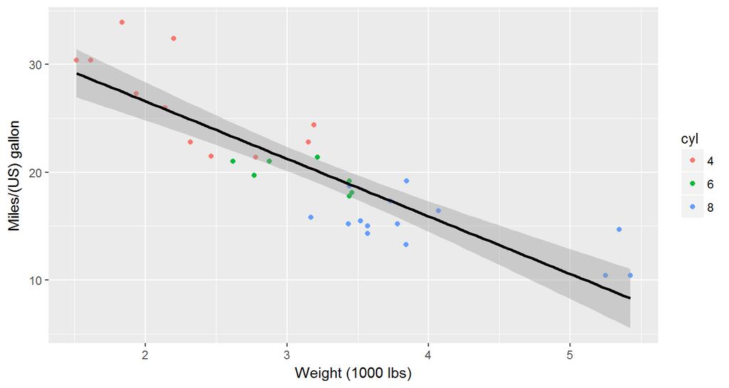

```r
  ggplot(mtc) + aes(x = wt, y = mpg, color = cyl) + geom_point() +
    xlab("Weight (1000 lbs)") + ylab("Miles/(US) gallon") +
    geom_smooth(method = lm, fullrange = TRUE, color = "black")
```

In the panels, the application will show: the plot, the current dataset and the sumary of the linear model for the `predictor - outcome` selected.

```r
  # Calculate linear model
  summary(lm(data = mtc, mpg ~ wt))
```

```
##
## Call:
## lm(formula = mpg ~ wt, data = mtc)
##
## Residuals:
##     Min      1Q  Median      3Q     Max
## -4.5432 -2.3647 -0.1252  1.4096  6.8727
##
## Coefficients:
##             Estimate Std. Error t value Pr(>|t|)
## (Intercept)  37.2851     1.8776  19.858  < 2e-16 ***
## wt           -5.3445     0.5591  -9.559 1.29e-10 ***
## ---
## Signif. codes:  0 '***' 0.001 '**' 0.01 '*' 0.05 '.' 0.1 ' ' 1
##
## Residual standard error: 3.046 on 30 degrees of freedom
## Multiple R-squared:  0.7528, Adjusted R-squared:  0.7446
## F-statistic: 91.38 on 1 and 30 DF,  p-value: 1.294e-10
```